# 03_gene_signature

Maryam Shojaei Shahrokhabadi

2026-01-07

```r
knitr::opts_chunk$set(echo = FALSE)
```

## 1. Introduction

The aim of this analysis is to develop a gene signature: a small set of genes that, combined in a classification rule, can distinguish acute myeloid leukemia (AML) from acute lymphoblastic leukemia (ALL). The data consist of 7,128 genes measured in 72 patients (47 ALL, 25 AML).

A good signature should be small enough to be practical, accurate on new patients, and stable, meaning that the same genes are selected when the data change slightly. Three questions are addressed:

1. Which classification method performs best?
2. How many genes should the signature contain?
3. Which genes form the final signature, and how well does it perform?

## 2. Preliminary Analysis: How Many Genes Differ?

Before building classifiers, each gene was tested for association with leukemia type using a gene-specific logistic regression. After multiple testing correction, 971 genes were significant when controlling the false discovery rate (Benjamini–Hochberg), and 7 under the stricter Holm correction. Figure 1 shows that many genes differ between the two leukemia types, in both directions.

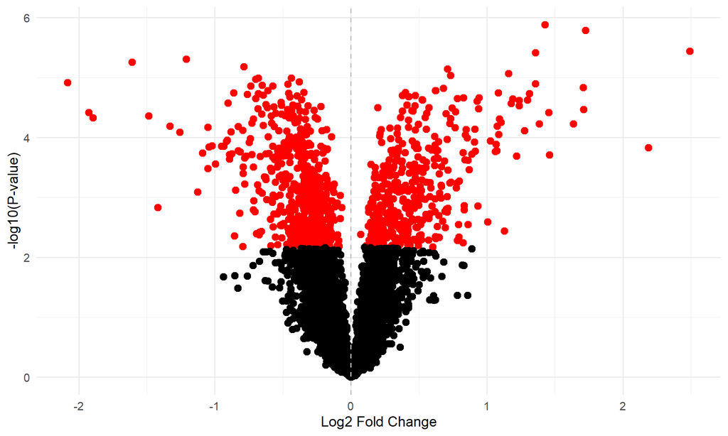

**Figure 1. Volcano plot of gene-specific tests. Red points are significant after BH correction.**

With hundreds of informative genes, the challenge is not finding signal but choosing a small, reliable subset of genes and a method that uses them well, while avoiding overfitting.

## 3. Methods

### 3.1 Classifiers

Five classification methods were compared:

- **Linear discriminant analysis (LDA)** assumes normally distributed classes with a common covariance matrix and estimates the full correlation structure between genes.
- **Diagonal LDA (DLDA)** makes the same assumptions but ignores correlations between genes, estimating only one variance per gene.
- **Support vector machine (SVM)** finds the boundary that separates the two classes with the largest margin.
- **LASSO** fits a penalised logistic regression that shrinks coefficients and sets some of them exactly to zero, performing its own variable selection.
- **Random forest (RF)** combines many decision trees built on random subsets of patients and genes.

### 3.2 Validation Strategy

A model’s accuracy on the data used to build it is overly optimistic. To estimate performance on new patients, Monte Carlo cross-validation (MCCV) was used:

1. The data were randomly split into a training set (2/3 of patients) and a test set (1/3), keeping the ALL/AML ratio the same in both.
2. Within the training set only, genes were ranked with a t-test and the top $K$ genes were selected.
3. The classifier was trained on these genes and evaluated on the test set.
4. This was repeated 100 times, and the misclassification error (MCE), sensitivity (AML correctly identified) and specificity (ALL correctly identified) were averaged over the 100 splits.

Performing gene selection inside each training set is essential. If genes were selected using all patients first, the test patients would already have influenced which genes were chosen, and the error estimate would be too optimistic (selection bias).

The analysis was repeated for signature sizes of $K = 5, 10, \dots, 45$ genes.

## 4. Results

### 4.1 Effect of Signature Size and Method

Figure 2 shows the cross-validated performance of each method as the number of genes increases.

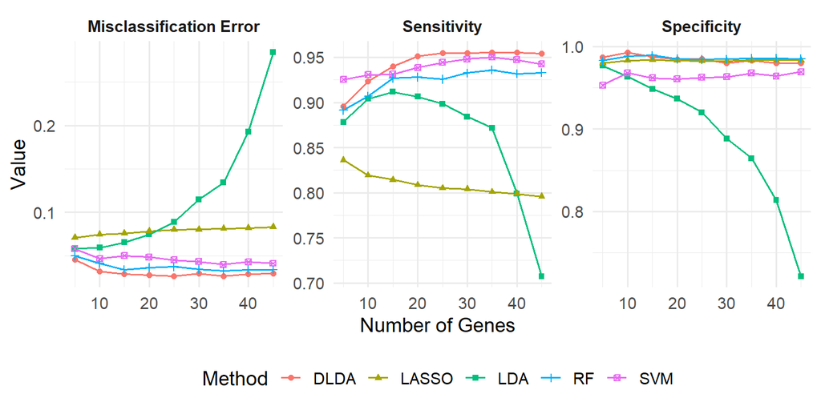

**Figure 2. Cross-validated misclassification error, sensitivity and specificity by number of genes, averaged over 100 MCCV splits.**

Three patterns stand out. First, **LDA deteriorates sharply as genes are added**. LDA estimates the full covariance matrix between genes, and with only about 48 training patients, this matrix becomes unstable once the number of genes approaches the number of patients. DLDA avoids this problem by ignoring correlations, and it is the most accurate method across almost all signature sizes. This illustrates a well-known result for high-dimensional data: a simpler model with fewer parameters often predicts better than a more flexible one.

Second, **LASSO has the lowest sensitivity**, meaning it misses more AML patients. LASSO was used with the default amount of penalisation, which removes many genes; tuning the penalty could improve its performance.

Third, for DLDA, SVM and RF, **performance stabilises at around 30 genes**: adding more genes beyond this point does not reduce the error further. A signature size of $K = 30$ was therefore chosen.

### 4.2 The Final Gene Signature

Since performance stabilised at around 30 genes, a signature size of $K = 30$ was used for classification. The final signature was derived in three steps:

1. **Choose the signature size:** $K = 30$, based on the results in Section 4.1.
2. **Repeat gene selection across splits:** in each of the 100 MCCV training sets, the 30 genes with the strongest t-test results were selected.
3. **Count how often each gene was selected:** genes selected in at least 50 of the 100 splits (50%) were retained.

This resulted in a final signature of 23 genes (Figure 3).

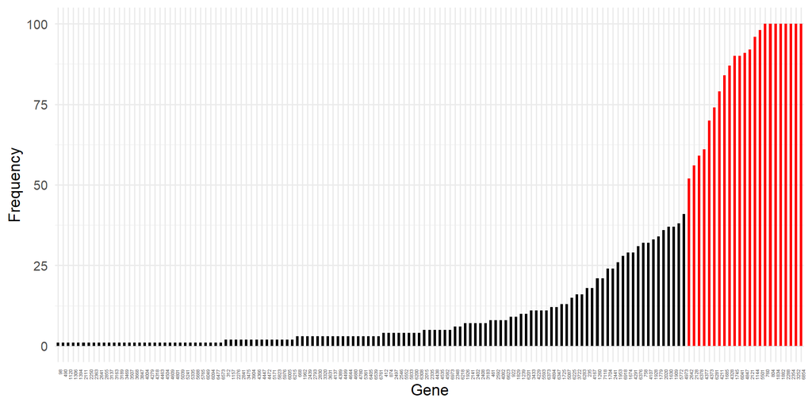

### 4.3 Performance of the Final Signature

**Table 3. Performance of each method using the fixed gene signature.**

| Metric | LDA | DLDA | SVM | LASSO | RF |
| --- | --- | --- | --- | --- | --- |
| MCE | 0.07 | 0.01 | 0.03 | 0.09 | 0.03 |
| Specificity | 0.93 | 1.00 | 0.97 | 0.98 | 0.99 |
| Sensitivity | 0.92 | 0.96 | 0.96 | 0.79 | 0.95 |